# SEM Beispiel 1

2023-06-14

## Motivation

Angenommen, du bist ein Forscher, der die Auswirkungen der Herkunft der Schüler auf die schulischen Leistungen untersucht. Du bekommst ein Datensatz von Schülern mit jeweils 9 beobachteten Variablen hochgeladen: Motivation, Harmonie, Stabilität, negative elterliche Psychologie, SES, verbaler IQ, Lesen, Arithmetik und Rechtschreibung. Der Studienleiter geht von drei latenten Konstrukten aus: Anpassung, Risiko und Leistung, die mit der folgenden Codebuch-Zuordnung gemessen werden:

Anpassung

- `motiv` Motivation
- `harm` Harmony
- `stabi` Stability

Risiko

- `ppsych` (Negative) Parental Psychology
- `ses` SES
- `verbal` Verbal IQ

Leistung

- `read` Reading
- `arith` Arithmetic
- `spell` Spelling

Anschauen des Datensatzes

```r
set.seed(42)    # Niemals vergessen!
summary(dat)
```

```
##      motiv               harm               stabi              ppsych
##  Min.   :-33.9712   Min.   :-32.98229   Min.   :-25.9214   Min.   :-31.0939
##  1st Qu.: -7.1480   1st Qu.: -6.05006   1st Qu.: -6.9361   1st Qu.: -6.5397
##  Median :  0.3155   Median :  0.00679   Median :  0.3016   Median : -0.5439
##  Mean   :  0.0000   Mean   :  0.00000   Mean   :  0.0000   Mean   :  0.0000
##  3rd Qu.:  6.7085   3rd Qu.:  6.62110   3rd Qu.:  7.4554   3rd Qu.:  6.7307
##  Max.   : 26.4690   Max.   : 31.16372   Max.   : 29.6349   Max.   : 33.2828
##       ses               verbal               read             arith
##  Min.   :-32.1370   Min.   :-37.60733   Min.   :-32.839   Min.   :-26.7009
##  1st Qu.: -6.3284   1st Qu.: -6.86543   1st Qu.: -6.843   1st Qu.: -6.4011
##  Median : -0.3117   Median :  0.04975   Median : -0.043   Median :  0.1266
##  Mean   :  0.0000   Mean   :  0.00000   Mean   :  0.000   Mean   :  0.0000
##  3rd Qu.:  6.3039   3rd Qu.:  6.23002   3rd Qu.:  6.657   3rd Qu.:  6.5697
##  Max.   : 29.0963   Max.   : 27.65674   Max.   : 27.606   Max.   : 33.0483
##      spell
##  Min.   :-31.360980
##  1st Qu.: -6.318838
##  Median : -0.009114
##  Mean   :  0.000000
##  3rd Qu.:  6.340824
##  Max.   : 26.932760
```

Die wichtigste Komponente eines Strukturgleichungsmodells ist die Kovarianz bzw. die statistische Beziehung zwischen den Größen.

```r
cov(dat)
```

```
##        motiv harm stabi ppsych ses verbal read arith spell
## motiv    100   77    59    -25  25     32   53    60    59
## harm      77  100    58    -25  26     25   42    44    45
## stabi     59   58   100    -16  18     27   36    38    38
## ppsych   -25  -25   -16    100 -42    -40  -39   -24   -31
## ses       25   26    18    -42 100     40   43    37    33
## verbal    32   25    27    -40  40    100   56    49    48
## read      53   42    36    -39  43     56  100    73    87
## arith     60   44    38    -24  37     49   73   100    72
## spell     59   45    38    -31  33     48   87    72   100
```

#### Interpretation

Die Diagonalen bilden die Varianzen der Items und die Off-Diagonalen die Kovarianzen. Beachte, dass die Varianz aller Variablen in unserer Studie zufällig 100 beträgt (entlang der Diagonalen). Betrachtet man die Beziehungen zwischen den Variablen (die Elemente auf den Außendiagonalen), so ist zu beachten, dass eine positive Kovarianz bedeutet, dass ein Element zunimmt, wenn das andere zunimmt, eine negative Kovarianz bedeutet, dass ein Element zunimmt, wenn das andere abnimmt. Die Kovarianz von `motiv` und `ppsych` beträgt `-25`, was bedeutet, dass die Motivation der Schüler mit zunehmender negativer elterlicher Psychologie abnimmt.

$\rightarrow$ Weiter in den Slides.

## Simple regression

Weiter mit dem Beispiel aus den Slides.

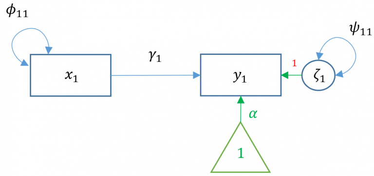

Wir bauen ein einfaches Lineares Modell

```r
m1a <- lm(read ~ motiv, data=dat)
summary(m1a)
```

```
##
## Call:
## lm(formula = read ~ motiv, data = dat)
##
## Residuals:
##      Min       1Q   Median       3Q      Max
## -26.0995  -6.1109   0.2342   5.2237  24.0183
##
## Coefficients:
##               Estimate Std. Error t value Pr(>|t|)
## (Intercept) -1.232e-07  3.796e-01    0.00        1
## motiv        5.300e-01  3.800e-02   13.95   <2e-16 ***
## ---
## Signif. codes:  0 '***' 0.001 '**' 0.01 '*' 0.05 '.' 0.1 ' ' 1
##
## Residual standard error: 8.488 on 498 degrees of freedom
## Multiple R-squared:  0.2809, Adjusted R-squared:  0.2795
## F-statistic: 194.5 on 1 and 498 DF,  p-value: < 2.2e-16
```

Wir können das selbe Modell auch mit dem `lavaan` Package bauen. Dieses Package ist extra dafür gebaut worden um SEMs zu bauen und zu nutzen.

```r
# Generelle Schreibweise:
## Modellgleichung
mgl <- '# regressions
       y ~ 1 + Variablen
       # variance (optional)
       Variable(n) ~~ Variable(n)'
## Modell Fitten
model <- sem(mgl, data=datensatz)
```

Die Syntax ist `lm()` insofern sehr ähnlich, als `read ~ motiv` den Prädiktor motiv auf das Ergebnis read angibt. Der Intercept ist jedoch standardmäßig nicht in der Ausgabe enthalten, sondern wird impliziert. Wenn wir einen Intercept hinzufügen wollen, müssen wir `read ~ 1 + motiv` einschließen. Optional können Sie die Varianz von motiv mit `motiv ~~ motiv` abfragen. Wenn diese Syntax nicht angegeben wird, wird der Parameter zwar geschätzt, aber nur implizit angegeben.

```r
library(lavaan)
fit1b <- sem(c('# Regressions part
                read ~ 1 + motiv
                # Varianz (optional)
                motiv ~~ motiv'),
             data=dat)
summary(fit1b)
```

```
## lavaan 0.6.15 ended normally after 8 iterations
##
##   Estimator                                         ML
##   Optimization method                           NLMINB
##   Number of model parameters                         5
##
##   Number of observations                           500
##
## Model Test User Model:
##
##   Test statistic                                 0.000
##   Degrees of freedom                                 0
##
## Parameter Estimates:
##
##   Standard errors                             Standard
##   Information                                 Expected
##   Information saturated (h1) model          Structured
##
## Regressions:
##                    Estimate  Std.Err  z-value  P(>|z|)
##   read ~
##     motiv             0.530    0.038   13.975    0.000
##
## Intercepts:
##                    Estimate  Std.Err  z-value  P(>|z|)
##    .read             -0.000    0.379   -0.000    1.000
##     motiv             0.000    0.447    0.000    1.000
##
## Variances:
##                    Estimate  Std.Err  z-value  P(>|z|)
##     motiv            99.800    6.312   15.811    0.000
##    .read             71.766    4.539   15.811    0.000
```

Der Achsenabschnitt von `.read (-0,000)` und der Regressionskoeffizient von `read ~ motiv (0,530)` entsprechen mit kleinen Rundungsfehlern der Ausgabe von `lm()`. Beachten Sie, dass das `.` vor dem Parameter eine endogene Variable unter Achsenabschnitte und eine Restvarianz unter Varianzen oder Kovarianzen angibt. Der Achsenabschnitt für das `motiv (0,000)` hat kein `.` und seine `Varianz (99,800)` auch nicht, was bedeutet, dass es sich um einen exogenen Mittelwert und eine exogene Varianz handelt. Der exogene Mittelwert und die exogene Varianz sollten eng mit dem univariaten Mittelwert (0) und der Varianz (100) übereinstimmen, wie unten gezeigt:

```r
mean(dat$motiv)
```

```
## [1] 2.4e-07
```

```r
var(dat$motiv)
```

```
## [1] 100
```

$\rightarrow$ Weiter in den Slides.

## Multiple regression

Die einfache Regression ist auf eine einzige exogene Variable beschränkt. In der Praxis kann ein Forscher daran interessiert sein, wie eine Gruppe von exogenen Variablen ein Ergebnis vorhersagt. Angenommen, wir haben immer noch ein endogenes Ergebnis, aber zwei oder mehr exogene Prädiktoren; dies wird als multiple Regression bezeichnet (nicht zu verwechseln mit multivariater Regression). Die Matrixform ermöglicht es uns, die Gleichung für alle Beobachtungen prägnant darzustellen
$$y_1 = \alpha_1 + \mathbf{x \gamma} + \zeta_1$$

Angenommen, wir haben zwei exogene Variablen die eine einzige endogene Variable vorhersagen. Das Pfaddiagramm für diese multiple Regression (Modell 2) lautet

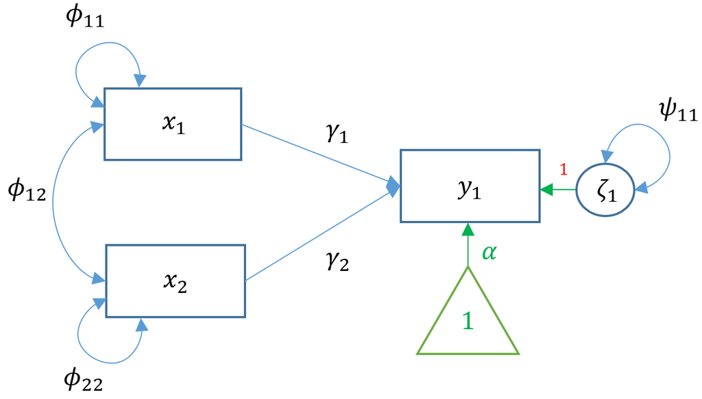

Die Spezifikation einer multiplen Regression in Lavaan ist so einfach wie das Hinzufügen eines weiteren Prädiktors. Angenommen, der Forscher ist daran interessiert, wie negative elterliche Psychologie `ppsych` und `motiv` motivieren, die Leseergebnisse der Schüler vorherzusagen.

```r
m2 <- sem(c('# regressions
                read ~ 1 + ppsych + motiv
                # covariance
                ppsych ~~ motiv'),
             data=dat)

fit2 <- sem(m2, data=dat)

summary(fit2)
```

```
## lavaan 0.6.15 ended normally after 1 iteration
##
##   Estimator                                         ML
##   Optimization method                           NLMINB
##   Number of model parameters                         9
##
##   Number of observations                           500
##
## Model Test User Model:
##
##   Test statistic                                 0.000
##   Degrees of freedom                                 0
##
## Parameter Estimates:
##
##   Standard errors                             Standard
##   Information                                 Expected
##   Information saturated (h1) model          Structured
##
## Regressions:
##                    Estimate  Std.Err  z-value  P(>|z|)
##   read ~
##     ppsych           -0.275    0.037   -7.385    0.000
##     motiv             0.461    0.037   12.404    0.000
##
## Covariances:
##                    Estimate  Std.Err  z-value  P(>|z|)
##   ppsych ~~
##     motiv           -24.950    4.601   -5.423    0.000
##
## Intercepts:
##                    Estimate  Std.Err  z-value  P(>|z|)
##    .read             -0.000    0.360   -0.000    1.000
##     ppsych           -0.000    0.447   -0.000    1.000
##     motiv             0.000    0.447    0.000    1.000
##
## Variances:
##                    Estimate  Std.Err  z-value  P(>|z|)
##    .read             64.708    4.092   15.811    0.000
##     ppsych           99.800    6.312   15.811    0.000
##     motiv            99.800    6.312   15.811    0.000
```

$\rightarrow$ Weiter in den Slides.

$\Gamma$ wird als Strukturparameter bezeichnet und definiert die Beziehung zwischen exogenen und endogenen Variablen.

```r
m3a <- 'read ~ 1 + ppsych + motiv
        arith ~ 1 + motiv'
fit3a <- sem(m3a, data=dat)
summary(fit3a)
```

```
## lavaan 0.6.15 ended normally after 17 iterations
##
##   Estimator                                         ML
##   Optimization method                           NLMINB
##   Number of model parameters                         8
##
##   Number of observations                           500
##
## Model Test User Model:
##
##   Test statistic                                 6.796
##   Degrees of freedom                                 1
##   P-value (Chi-square)                           0.009
##
## Parameter Estimates:
##
##   Standard errors                             Standard
##   Information                                 Expected
##   Information saturated (h1) model          Structured
##
## Regressions:
##                    Estimate  Std.Err  z-value  P(>|z|)
##   read ~
##     ppsych           -0.216    0.030   -7.289    0.000
##     motiv             0.476    0.037   12.918    0.000
##   arith ~
##     motiv             0.600    0.036   16.771    0.000
##
## Covariances:
##                    Estimate  Std.Err  z-value  P(>|z|)
##  .read ~~
##    .arith            39.179    3.373   11.615    0.000
##
## Intercepts:
##                    Estimate  Std.Err  z-value  P(>|z|)
##    .read             -0.000    0.361   -0.000    1.000
##    .arith            -0.000    0.357   -0.000    1.000
##
## Variances:
##                    Estimate  Std.Err  z-value  P(>|z|)
##    .read             65.032    4.113   15.811    0.000
##    .arith            63.872    4.040   15.811    0.000
```

```r
m3b <- lm(read ~ ppsych + motiv, data=dat)
(fit3b <- summary(m3b))
```

```
##
## Call:
## lm(formula = read ~ ppsych + motiv, data = dat)
##
## Residuals:
##      Min       1Q   Median       3Q      Max
## -21.7734  -5.5633   0.1389   5.3662  25.8209
##
## Coefficients:
##               Estimate Std. Error t value Pr(>|t|)
## (Intercept) -1.336e-07  3.608e-01   0.000        1
## ppsych      -2.747e-01  3.730e-02  -7.363 7.51e-13 ***
## motiv        4.613e-01  3.730e-02  12.367  < 2e-16 ***
## ---
## Signif. codes:  0 '***' 0.001 '**' 0.01 '*' 0.05 '.' 0.1 ' ' 1
##
## Residual standard error: 8.068 on 497 degrees of freedom
## Multiple R-squared:  0.3516, Adjusted R-squared:  0.349
## F-statistic: 134.8 on 2 and 497 DF,  p-value: < 2.2e-16
```

Führen wir nun das Modell von arith auf motiv in lm() aus

```r
m3c <- lm(arith ~ motiv, data=dat)
(fit3c <- summary(m3c))
```

```
##
## Call:
## lm(formula = arith ~ motiv, data = dat)
##
## Residuals:
##     Min      1Q  Median      3Q     Max
## -23.633  -5.341  -0.214   5.106  21.271
##
## Coefficients:
##               Estimate Std. Error t value Pr(>|t|)
## (Intercept) -5.400e-08  3.581e-01    0.00        1
## motiv        6.000e-01  3.585e-02   16.74   <2e-16 ***
## ---
## Signif. codes:  0 '***' 0.001 '**' 0.01 '*' 0.05 '.' 0.1 ' ' 1
##
## Residual standard error: 8.008 on 498 degrees of freedom
## Multiple R-squared:   0.36,  Adjusted R-squared:  0.3587
## F-statistic: 280.1 on 1 and 498 DF,  p-value: < 2.2e-16
```

$\rightarrow$ Weiter in den Slides.

## Multivariate Regression zur Entfernung von Standardkovarianzen

Eine Antwort auf die obrige Frage ist dass `lm()` den Klein-Quadrate Schätzer benutzt, während `laavan`auf der Maximum-likelihood Methode basiert, daher der Unterschied in den Schätzungen der Restvarianz. Unabhängig davon, welcher der beiden Schätzer verwendet wird, sollten die Regressionskoeffizienten jedoch unverzerrt sein, so dass der Unterschied in den Koeffizienten auf etwas anderes zurückzuführen sein muss. Die Antwort liegt in der impliziten Tatsache, dass lavaan standardmäßig die Residualvarianzen der endogenen Variablen `.read ~~ .arith` kovariiert. Entfernt man die Standard-Residualkovarianzen, sieht man im Pfaddiagramm.

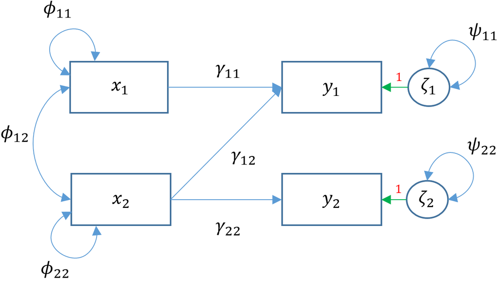

Removing the covariance of `read` and `arith` is the same as fixing its covariance to zero through the following syntax `read ~~ 0*arith`.

```r
m3d <- '# regressions
        read ~ 1 + ppsych + motiv
        arith ~ 1 + motiv
        # covariance
        read ~~ 0*arith
        '

fit3d <- sem(m3d, data=dat)

summary(fit3d)
```

```
## lavaan 0.6.15 ended normally after 2 iterations
##
##   Estimator                                         ML
##   Optimization method                           NLMINB
##   Number of model parameters                         7
##
##   Number of observations                           500
##
## Model Test User Model:
##
##   Test statistic                               234.960
##   Degrees of freedom                                 2
##   P-value (Chi-square)                           0.000
##
## Parameter Estimates:
##
##   Standard errors                             Standard
##   Information                                 Expected
##   Information saturated (h1) model          Structured
##
## Regressions:
##                    Estimate  Std.Err  z-value  P(>|z|)
##   read ~
##     ppsych           -0.275    0.037   -7.385    0.000
##     motiv             0.461    0.037   12.404    0.000
##   arith ~
##     motiv             0.600    0.036   16.771    0.000
##
## Covariances:
##                    Estimate  Std.Err  z-value  P(>|z|)
##  .read ~~
##    .arith             0.000
##
## Intercepts:
##                    Estimate  Std.Err  z-value  P(>|z|)
##    .read              0.000    0.360    0.000    1.000
##    .arith             0.000    0.357    0.000    1.000
##
## Variances:
##                    Estimate  Std.Err  z-value  P(>|z|)
##    .read             64.708    4.092   15.811    0.000
##    .arith            63.872    4.040   15.811    0.000
```